# leaflethex

## The Purpose for Leaflethex

Leaflethex is primarily a proof of concept for rendering leafletJS functionality in R by running the javascript though an htmlwidget.

It also contains a function `addHexbin()` for applying a hexbin layer to a leaflet map

## How to use leaflethex for the Hexbin Layer

If you are interested in using the hexbin plugin that comes along with leaflethex, the function `addHexbin()` can be used which has a similar API to the rest of the Leaflet R functions that add layers to leaflet maps such as `leaflet::addCircles()`, `leaflet::addMarkers()`, etc.

The default use bins geopoints into hexagonal regions and used size and/or color to represent the number of points in each bin.

```r
# Randomly generated data points
data_points <- tibble(
  lat =  42.9634 + rnorm(1000),
  lng = -85.6681 + rnorm(1000)
)
# Create map with data points
leaflet::leaflet(data_points) %>% addTiles() %>% addHexbin()
```

[interactive chart not shown]

## Features of addHexbin()

Radius, color, and opacity of hexagon are easily modified using arguments to `addHexbin()`. As with other leaflet functions, data is inherited from the map unless specified with the `data` argument.

For a more complete description of `addHexbin()`, see the function help and package vignettes.

```r
data_points <- tibble(
  lat =  42.9634 + rnorm(1000),
  lng = -85.6681 + rnorm(1000)
)
data_points2 <- tibble(
  lat =  42.9634 + rnorm(1000),
  lng = -95.6681 + rnorm(1000)
)
leaflet::leaflet(rbind(data_points, data_points2)) %>%
         addTiles() %>%
         addHexbin(data = data_points) %>%
         addHexbin(data = data_points2,
                    lowEndColor  = "yellow",
                    highEndColor = "red")
```

[interactive chart not shown]

## Using leaflethex for arbitrary LeafletJS functionality: Overview

Leaflethex also provides a mechanism for creating hooks to arbitrary javascript code via `pluginFactory()`. To modify existing javascript code that modfies a leaflet map so that it can be used from within R using the leaflet R package

1. Load the JS code that modifies a map object.

   (In the example below, this file will be called `deps.js`.)
5. Create the plugin with `pluginFactory()`.

   ```r
     new_plugin <-
       pluginFactory(
         "Name of Plugin",
         "path/of/parent/folder/",
         "leaflet-script.js",
         "deps.js",
         "stylesheet.css")
     # Create a basic leaflet map
     leaflet::leaflet() %>% addTiles() %>% new_plugin()
   ```

## Step by Step how to create a new plugin with `pluginFactory()`

1. In javascript
   1. Copy the javascript code into a .js file then wrap the code in a `function()` as below

      ```javascript
      function(el, x, data = null) {
        // Your JS Code
      }
      ```

   2. Now modify this file to use the data argument as needed, this argument will be used for data points but also mapping options like radius or color or anything else one needs to pass into the js function.
2. In R.
   1. create a plugin with the `pluginFactory()` function.

      ```r
      addPluginName <-
          pluginFactory(
                  "Name of Plugin",
                  system.file("folder_containing_js_file", ""),
                  "name_of_file.js",
                  "dependencies_required.js",
                  "stylesheet_for_js.css")
      ```

      When adding style sheets, make sure the .css file is in the same location as the js folder
   2. Apply the plugin to the map

      ```r
        map %>% addPluginName(data = mapData,
                              radius = radius,
                              opacity = opacity,
                              duration = duration,
                              lowEndColor = lowEndColor,
                              highEndColor = highEndColor)
      ```

      Using the leaflethex plugin parameters as an example, any parameters passed in to the addPluginName() function will be taken as dots and translated into a JSON object in the javascript side.
   3. The object appears in the JS World as a JSON Object named `data`

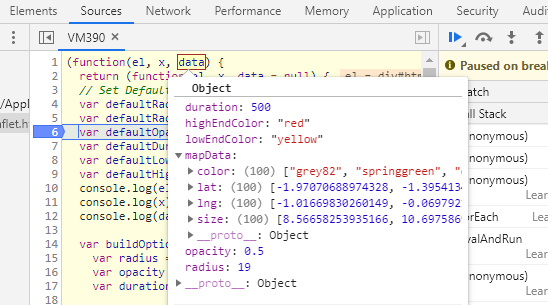

   JS-Data

3. Differences between creating the plugin locally and creating a new package

   When simply creating the plugin and running it locally the `pluginFactory()` will work as expected in this example; however, when creating a package there are a few things that need tweaking:
   1. Any time `system.file()` is used, the `package` parameter must be set to the new package like so:

   ````
    ```r
    addPluginName <-
        pluginFactory(
                "Name of Plugin",
                system.file("folder_containing_js_file", "", package = "your_package_name"), # Add the package parameter
                "name_of_file.js",
                "dependencies_required.js",
                "stylesheet_for_js.css")
    ```
   ````

   1. Secondly, the js folder must be inside the `inst` folder in order to be installed when the package is installed, otherwise Rstudio will complain that the js folder doesn’t exist.